# Notebook

No clear separation by tenure and cashback alone → other factors also drive churn.

```python
# check unique values in order to saprate data
df.nunique()
```

|  | 0 |
| --- | --- |
| CustomerID | 5630 |
| Churn | 2 |
| Tenure | 37 |
| CityTier | 3 |
| WarehouseToHome | 35 |
| HourSpendOnApp | 7 |
| NumberOfDeviceRegistered | 6 |
| SatisfactionScore | 5 |
| NumberOfAddress | 15 |
| Complain | 2 |
| OrderAmountHikeFromlastYear | 17 |
| CouponUsed | 18 |
| OrderCount | 17 |
| DaySinceLastOrder | 23 |
| CashbackAmount | 220 |
| PreferredLoginDevice_Mobile Phone | 2 |
| PreferredLoginDevice_Phone | 2 |
| PreferredPaymentMode_COD | 2 |
| PreferredPaymentMode_Cash on Delivery | 2 |
| PreferredPaymentMode_Credit Card | 2 |
| PreferredPaymentMode_Debit Card | 2 |
| PreferredPaymentMode_E wallet | 2 |
| PreferredPaymentMode_UPI | 2 |
| Gender_Male | 2 |
| PreferedOrderCat_Grocery | 2 |
| PreferedOrderCat_Laptop & Accessory | 2 |
| PreferedOrderCat_Mobile | 2 |
| PreferedOrderCat_Mobile Phone | 2 |
| PreferedOrderCat_Others | 2 |
| MaritalStatus_Married | 2 |
| MaritalStatus_Single | 2 |

**dtype:** int64

```python
# data info
df.info()
```

```
<class 'pandas.core.frame.DataFrame'>
RangeIndex: 5630 entries, 0 to 5629
Data columns (total 31 columns):
 #   Column                                 Non-Null Count  Dtype
---  ------                                 --------------  -----
 0   CustomerID                             5630 non-null   int64
 1   Churn                                  5630 non-null   int64
 2   Tenure                                 5630 non-null   float64
 3   CityTier                               5630 non-null   int64
 4   WarehouseToHome                        5630 non-null   float64
 5   HourSpendOnApp                         5630 non-null   float64
 6   NumberOfDeviceRegistered               5630 non-null   int64
 7   SatisfactionScore                      5630 non-null   int64
 8   NumberOfAddress                        5630 non-null   int64
 9   Complain                               5630 non-null   int64
```

[output cut: 23 more lines]

```python
# pre-processing modules from sklearn
from sklearn.preprocessing import LabelEncoder
from sklearn.preprocessing import StandardScaler

#customer id col
Id_col     = ['CustomerID'] # Corrected ID column name

#Target columns
target_col = ["Churn"]

#categorical columns
# any columns which has more than 6 categories
# Corrected DataFrame name from telcom to df
cat_cols   = df.nunique()[df.nunique() < 6].keys().tolist()
cat_cols   = [x for x in cat_cols if x not in target_col and x not in Id_col] # Exclude target and ID from categorical columns

#numerical columns
# any columns which is not category, traget or ID
# Corrected DataFrame name from telcom to df
num_cols   = [x for x in df.columns if x not in cat_cols + target_col + Id_col]

#Binary columns with 2 values
# Corrected DataFrame name from telcom to df
bin_cols   = df.nunique()[df.nunique() == 2].keys().tolist()
# Columns more than 2 values
multi_cols = [i for i in cat_cols if i not in bin_cols]

print("ID column:", Id_col)
print("Target column:", target_col)
print("Categorical columns (< 6 unique values, excluding ID and Target):", cat_cols)
print("Numerical columns:", num_cols)
print("Binary columns (2 unique values):", bin_cols)
print("Multi-category columns (> 2 unique values in categorical_cols):", multi_cols)
```

```
ID column: ['CustomerID']
Target column: ['Churn']
Categorical columns (< 6 unique values, excluding ID and Target): ['CityTier', 'SatisfactionScore', 'Complain', 'PreferredLoginDevice_Mobile Phone', 'PreferredLoginDevice_Phone', 'PreferredPaymentMode_COD', 'PreferredPaymentMode_Cash on Delivery', 'PreferredPaymentMode_Credit Card', 'PreferredPaymen…
Numerical columns: ['Tenure', 'WarehouseToHome', 'HourSpendOnApp', 'NumberOfDeviceRegistered', 'NumberOfAddress', 'OrderAmountHikeFromlastYear', 'CouponUsed', 'OrderCount', 'DaySinceLastOrder', 'CashbackAmount']
Binary columns (2 unique values): ['Churn', 'Complain', 'PreferredLoginDevice_Mobile Phone', 'PreferredLoginDevice_Phone', 'PreferredPaymentMode_COD', 'PreferredPaymentMode_Cash on Delivery', 'PreferredPaymentMode_Credit Card', 'PreferredPaymentMode_Debit Card', 'PreferredPaymentMode_E wallet', 'Pre…
Multi-category columns (> 2 unique values in categorical_cols): ['CityTier', 'SatisfactionScore']
```

```python
#Label encoding Binary columns
le = LabelEncoder()
for i in bin_cols :
    df[i] = le.fit_transform(df[i])

#Duplicating columns for multi value columns
telcom = pd.get_dummies(data = df,columns = multi_cols)
```

```python
# data overview:
df.head()
```

|  | CustomerID | Churn | Tenure | CityTier | WarehouseToHome | HourSpendOnApp | NumberOfDeviceRegistered | SatisfactionScore | NumberOfAddress | Complain | ... | PreferredPaymentMode_E wallet | PreferredPaymentMode_UPI | Gender_Male | PreferedOrderCat_Grocery | PreferedOrderCat_Laptop & Accessory | PreferedOrderCat_Mobile | PreferedOrderCat_Mobile Phone | PreferedOrderCat_Others | MaritalStatus_Married | MaritalStatus_Single |
| --- | --- | --- | --- | --- | --- | --- | --- | --- | --- | --- | --- | --- | --- | --- | --- | --- | --- | --- | --- | --- | --- |
| 0 | 50001 | 1 | 4.000000 | 3 | 6.0 | 3.000000 | 3 | 2 | 9 | 1 | ... | 0 | 0 | 0 | 0 | 1 | 0 | 0 | 0 | 0 | 1 |
| 1 | 50002 | 1 | 10.189899 | 1 | 8.0 | 3.000000 | 4 | 3 | 7 | 1 | ... | 0 | 1 | 1 | 0 | 0 | 1 | 0 | 0 | 0 | 1 |
| 2 | 50003 | 1 | 10.189899 | 1 | 30.0 | 2.000000 | 4 | 3 | 6 | 1 | ... | 0 | 0 | 1 | 0 | 0 | 1 | 0 | 0 | 0 | 1 |
| 3 | 50004 | 1 | 0.000000 | 3 | 15.0 | 2.000000 | 4 | 5 | 8 | 0 | ... | 0 | 0 | 1 | 0 | 1 | 0 | 0 | 0 | 0 | 1 |
| 4 | 50005 | 1 | 0.000000 | 1 | 12.0 | 2.931535 | 3 | 5 | 3 | 0 | ... | 0 | 0 | 1 | 0 | 0 | 1 | 0 | 0 | 0 | 1 |

5 rows × 31 columns

```python
#Scaling Numerical columns
std = StandardScaler()
scaled = std.fit_transform(df[num_cols])
scaled = pd.DataFrame(scaled,columns=num_cols)
```

```python
# check out scaled data
scaled
```

|  | Tenure | WarehouseToHome | HourSpendOnApp | NumberOfDeviceRegistered | NumberOfAddress | OrderAmountHikeFromlastYear | CouponUsed | OrderCount | DaySinceLastOrder | CashbackAmount |
| --- | --- | --- | --- | --- | --- | --- | --- | --- | --- | --- |
| 0 | -0.741002 | -1.156091 | 0.097069 | -0.672900 | 1.852616 | -1.312273 | -0.405767 | -0.699345 | 1.284833e-01 | -0.350105 |
| 1 | 0.000000 | -0.916235 | 0.097069 | 0.303750 | 1.078430 | -0.197324 | -0.946053 | -0.699345 | -1.278752e+00 | -1.142957 |
| 2 | 0.000000 | 1.722175 | -1.320723 | 0.303750 | 0.691336 | -0.476062 | -0.946053 | -0.699345 | -4.344109e-01 | -1.163287 |
| 3 | -1.219847 | -0.076741 | -1.320723 | 0.303750 | 1.465523 | 2.032574 | -0.946053 | -0.699345 | -4.344109e-01 | -0.878673 |
| 4 | -1.219847 | -0.436525 | 0.000000 | -0.672900 | -0.469944 | -1.312273 | -0.405767 | -0.699345 | -4.344109e-01 | -0.959991 |
| ... | ... | ... | ... | ... | ... | ... | ... | ... | ... | ... |
| 5625 | -0.022733 | 1.722175 | 0.097069 | -1.649551 | 0.691336 | 0.638888 | -0.405767 | -0.351066 | -1.529638e-01 | -0.533071 |
| 5626 | 0.336401 | -0.316597 | 0.097069 | 1.280401 | 0.691336 | 0.081413 | -0.405767 | -0.351066 | -2.499752e-16 | 0.971315 |
| 5627 | -1.100136 | -0.556452 | 0.097069 | -1.649551 | -0.469944 | 1.475100 | -0.405767 | -0.351066 | -1.529638e-01 | 0.178463 |
| 5628 | 1.533515 | -0.796308 | 1.514862 | 1.280401 | -0.082850 | -0.197324 | 0.134518 | -0.351066 | 1.254272e+00 | 0.036156 |
| 5629 | -0.262156 | -0.076741 | 0.097069 | -1.649551 | -0.082850 | -0.754799 | 0.134518 | -0.351066 | -4.344109e-01 | -0.167139 |

5630 rows × 10 columns

```python
# drop numeric columns and add scaled column
#basically we are replacing columns with scaled data
df = df.drop(columns = num_cols,axis = 1)
df1 = df.merge(scaled,left_index=True,right_index=True,how = "left")

df1.head()
```

|  | CustomerID | Churn | CityTier | SatisfactionScore | Complain | PreferredLoginDevice_Mobile Phone | PreferredLoginDevice_Phone | PreferredPaymentMode_COD | PreferredPaymentMode_Cash on Delivery | PreferredPaymentMode_Credit Card | ... | Tenure | WarehouseToHome | HourSpendOnApp | NumberOfDeviceRegistered | NumberOfAddress | OrderAmountHikeFromlastYear | CouponUsed | OrderCount | DaySinceLastOrder | CashbackAmount |
| --- | --- | --- | --- | --- | --- | --- | --- | --- | --- | --- | --- | --- | --- | --- | --- | --- | --- | --- | --- | --- | --- |
| 0 | 50001 | 1 | 3 | 2 | 1 | 1 | 0 | 0 | 0 | 0 | ... | -0.741002 | -1.156091 | 0.097069 | -0.67290 | 1.852616 | -1.312273 | -0.405767 | -0.699345 | 0.128483 | -0.350105 |
| 1 | 50002 | 1 | 1 | 3 | 1 | 0 | 1 | 0 | 0 | 0 | ... | 0.000000 | -0.916235 | 0.097069 | 0.30375 | 1.078430 | -0.197324 | -0.946053 | -0.699345 | -1.278752 | -1.142957 |
| 2 | 50003 | 1 | 1 | 3 | 1 | 0 | 1 | 0 | 0 | 0 | ... | 0.000000 | 1.722175 | -1.320723 | 0.30375 | 0.691336 | -0.476062 | -0.946053 | -0.699345 | -0.434411 | -1.163287 |
| 3 | 50004 | 1 | 3 | 5 | 0 | 0 | 1 | 0 | 0 | 0 | ... | -1.219847 | -0.076741 | -1.320723 | 0.30375 | 1.465523 | 2.032574 | -0.946053 | -0.699345 | -0.434411 | -0.878673 |
| 4 | 50005 | 1 | 1 | 5 | 0 | 0 | 1 | 0 | 0 | 0 | ... | -1.219847 | -0.436525 | 0.000000 | -0.67290 | -0.469944 | -1.312273 | -0.405767 | -0.699345 | -0.434411 | -0.959991 |

5 rows × 31 columns

## Variable Summary & Co-relation metrix

- Why we check variable summary?
- Why we check co-relation metrix?

** Variable summary:**This provides descriptive statistics for each column in the DataFrame. It helps to understand the central tendency, dispersion, and shape of your data. we can quickly see things like: Count: Number of non-null values, indicating missing data. Mean, Median (50th percentile): Typical values. Standard Deviation: How spread out the data is.

**Co-relation matrix **provides a foundational understanding of the data's structure, distribution, and relationships between variables before building machine learning models.

```python
# variable summary
summary = df.describe().transpose()
summary
```

|  | count | mean | std | min | 25% | 50% | 75% | max |
| --- | --- | --- | --- | --- | --- | --- | --- | --- |
| CustomerID | 5630.0 | 52815.500000 | 1625.385339 | 50001.0 | 51408.25 | 52815.5 | 54222.75 | 55630.0 |
| Churn | 5630.0 | 0.168384 | 0.374240 | 0.0 | 0.00 | 0.0 | 0.00 | 1.0 |
| CityTier | 5630.0 | 1.654707 | 0.915389 | 1.0 | 1.00 | 1.0 | 3.00 | 3.0 |
| SatisfactionScore | 5630.0 | 3.066785 | 1.380194 | 1.0 | 2.00 | 3.0 | 4.00 | 5.0 |
| Complain | 5630.0 | 0.284902 | 0.451408 | 0.0 | 0.00 | 0.0 | 1.00 | 1.0 |
| PreferredLoginDevice_Mobile Phone | 5630.0 | 0.491119 | 0.499966 | 0.0 | 0.00 | 0.0 | 1.00 | 1.0 |
| PreferredLoginDevice_Phone | 5630.0 | 0.218650 | 0.413367 | 0.0 | 0.00 | 0.0 | 0.00 | 1.0 |
| PreferredPaymentMode_COD | 5630.0 | 0.064831 | 0.246250 | 0.0 | 0.00 | 0.0 | 0.00 | 1.0 |
| PreferredPaymentMode_Cash on Delivery | 5630.0 | 0.026465 | 0.160529 | 0.0 | 0.00 | 0.0 | 0.00 | 1.0 |
| PreferredPaymentMode_Credit Card | 5630.0 | 0.266607 | 0.442225 | 0.0 | 0.00 | 0.0 | 1.00 | 1.0 |
| PreferredPaymentMode_Debit Card | 5630.0 | 0.411012 | 0.492061 | 0.0 | 0.00 | 0.0 | 1.00 | 1.0 |
| PreferredPaymentMode_E wallet | 5630.0 | 0.109059 | 0.311740 | 0.0 | 0.00 | 0.0 | 0.00 | 1.0 |
| PreferredPaymentMode_UPI | 5630.0 | 0.073535 | 0.261035 | 0.0 | 0.00 | 0.0 | 0.00 | 1.0 |
| Gender_Male | 5630.0 | 0.601066 | 0.489723 | 0.0 | 0.00 | 1.0 | 1.00 | 1.0 |
| PreferedOrderCat_Grocery | 5630.0 | 0.072824 | 0.259871 | 0.0 | 0.00 | 0.0 | 0.00 | 1.0 |
| PreferedOrderCat_Laptop & Accessory | 5630.0 | 0.364121 | 0.481225 | 0.0 | 0.00 | 0.0 | 1.00 | 1.0 |
| PreferedOrderCat_Mobile | 5630.0 | 0.143694 | 0.350811 | 0.0 | 0.00 | 0.0 | 0.00 | 1.0 |
| PreferedOrderCat_Mobile Phone | 5630.0 | 0.225755 | 0.418116 | 0.0 | 0.00 | 0.0 | 0.00 | 1.0 |
| PreferedOrderCat_Others | 5630.0 | 0.046892 | 0.211426 | 0.0 | 0.00 | 0.0 | 0.00 | 1.0 |
| MaritalStatus_Married | 5630.0 | 0.530373 | 0.499121 | 0.0 | 0.00 | 1.0 | 1.00 | 1.0 |
| MaritalStatus_Single | 5630.0 | 0.319005 | 0.466133 | 0.0 | 0.00 | 0.0 | 1.00 | 1.0 |

```python
#correlation
# Corrected the column name from 'customerID' to 'CustomerID'
correlation = df.drop('CustomerID', axis=1).corr()
#tick labels
matrix_cols = correlation.columns.tolist()
```

```python
#convert to array
corr_array  = np.array(correlation)
```

```python
# correlation
plt.figure(figsize=(20,10))
sns.set(font_scale=1.25)
```

```python
correlation
```

|  | Churn | CityTier | SatisfactionScore | Complain | PreferredLoginDevice_Mobile Phone | PreferredLoginDevice_Phone | PreferredPaymentMode_COD | PreferredPaymentMode_Cash on Delivery | PreferredPaymentMode_Credit Card | PreferredPaymentMode_Debit Card | PreferredPaymentMode_E wallet | PreferredPaymentMode_UPI | Gender_Male | PreferedOrderCat_Grocery | PreferedOrderCat_Laptop & Accessory | PreferedOrderCat_Mobile | PreferedOrderCat_Mobile Phone | PreferedOrderCat_Others | MaritalStatus_Married | MaritalStatus_Single |
| --- | --- | --- | --- | --- | --- | --- | --- | --- | --- | --- | --- | --- | --- | --- | --- | --- | --- | --- | --- | --- |
| Churn | 1.000000 | 0.084703 | 0.105481 | 0.250188 | -0.111639 | 0.078916 | 0.083933 | -0.006178 | -0.064131 | -0.032453 | 0.055751 | 0.004163 | 0.029264 | -0.089575 | -0.133353 | 0.113364 | 0.154387 | -0.054903 | -0.151024 | 0.180847 |
| CityTier | 0.084703 | 1.000000 | -0.011554 | 0.003375 | 0.109750 | -0.130023 | -0.035440 | -0.013965 | -0.137236 | -0.118713 | 0.514227 | -0.030518 | -0.025176 | 0.004160 | 0.226587 | -0.127602 | -0.188046 | -0.042998 | -0.029922 | 0.020878 |
| SatisfactionScore | 0.105481 | -0.011554 | 1.000000 | -0.031115 | -0.007636 | 0.048821 | 0.021234 | 0.013670 | 0.020594 | -0.050365 | 0.017752 | 0.008063 | -0.035220 | 0.002287 | -0.019501 | 0.005493 | 0.005577 | 0.001442 | -0.023576 | -0.019314 |
| Complain | 0.250188 | 0.003375 | -0.031115 | 1.000000 | -0.001381 | 0.003128 | -0.014367 | -0.008459 | -0.003238 | -0.009009 | 0.011450 | 0.021183 | -0.040269 | 0.013917 | -0.021304 | 0.006186 | 0.011191 | -0.013429 | -0.003720 | -0.001422 |
| PreferredLoginDevice_Mobile Phone | -0.111639 | 0.109750 | -0.007636 | -0.001381 | 1.000000 | -0.519682 | -0.072521 | 0.090361 | 0.085035 | -0.029931 | 0.113358 | -0.030387 | -0.039142 | 0.132140 | 0.093188 | -0.390276 | -0.099611 | 0.138390 | 0.027422 | -0.048062 |
| PreferredLoginDevice_Phone | 0.078916 | -0.130023 | 0.048821 | 0.003128 | -0.519682 | 1.000000 | 0.064910 | -0.044385 | -0.099315 | 0.002658 | -0.095470 | 0.040302 | 0.029915 | -0.148255 | -0.163639 | 0.487714 | 0.115219 | -0.117335 | -0.036069 | 0.037160 |
| PreferredPaymentMode_COD | 0.083933 | -0.035440 | 0.021234 | -0.014367 | -0.072521 | 0.064910 | 1.000000 | -0.043412 | -0.158751 | -0.219949 | -0.092120 | -0.074179 | 0.037728 | -0.073791 | -0.002855 | 0.058715 | 0.097658 | -0.058401 | -0.025419 | 0.030278 |
| PreferredPaymentMode_Cash on Delivery | -0.006178 | -0.013965 | 0.013670 | -0.008459 | 0.090361 | -0.044385 | -0.043412 | 1.000000 | -0.099410 | -0.137733 | -0.057686 | -0.046451 | -0.041939 | 0.055996 | -0.090272 | -0.010759 | -0.078444 | 0.026240 | 0.006595 | -0.013133 |
| PreferredPaymentMode_Credit Card | -0.064131 | -0.137236 | 0.020594 | -0.003238 | 0.085035 | -0.099315 | -0.158751 | -0.099410 | 1.000000 | -0.503666 | -0.210947 | -0.169863 | -0.023132 | 0.047444 | 0.017075 | -0.238971 | 0.109667 | 0.044871 | 0.013610 | -0.012778 |
| PreferredPaymentMode_Debit Card | -0.032453 | -0.118713 | -0.050365 | -0.009009 | -0.029931 | 0.002658 | -0.219949 | -0.137733 | -0.503666 | 1.000000 | -0.292267 | -0.235345 | 0.002310 | 0.021513 | -0.006434 | 0.024176 | -0.005524 | -0.014527 | -0.016842 | 0.023098 |
| PreferredPaymentMode_E wallet | 0.055751 | 0.514227 | 0.017752 | 0.011450 | 0.113358 | -0.095470 | -0.092120 | -0.057686 | -0.210947 | -0.292267 | 1.000000 | -0.098568 | -0.024500 | -0.001566 | 0.128403 | -0.091339 | -0.120776 | 0.003257 | 0.000401 | -0.019401 |
| PreferredPaymentMode_UPI | 0.004163 | -0.030518 | 0.008063 | 0.021183 | -0.030387 | 0.040302 | -0.074179 | -0.046451 | -0.169863 | -0.235345 | -0.098568 | 1.000000 | 0.043301 | -0.031817 | 0.004602 | 0.004870 | 0.020407 | 0.027641 | 0.036032 | -0.029300 |
| Gender_Male | 0.029264 | -0.025176 | -0.035220 | -0.040269 | -0.039142 | 0.029915 | 0.037728 | -0.041939 | -0.023132 | 0.002310 | -0.024500 | 0.043301 | 1.000000 | -0.048071 | -0.019739 | 0.017308 | 0.042552 | 0.033147 | 0.037225 | -0.032308 |
| PreferedOrderCat_Grocery | -0.089575 | 0.004160 | 0.002287 | 0.013917 | 0.132140 | -0.148255 | -0.073791 | 0.055996 | 0.047444 | 0.021513 | -0.001566 | -0.031817 | -0.048071 | 1.000000 | -0.212076 | -0.114805 | -0.151334 | -0.062163 | 0.008967 | -0.039293 |
| PreferedOrderCat_Laptop & Accessory | -0.133353 | 0.226587 | -0.019501 | -0.021304 | 0.093188 | -0.163639 | -0.002855 | -0.090272 | 0.017075 | -0.006434 | 0.128403 | 0.004602 | -0.019739 | -0.212076 | 1.000000 | -0.309985 | -0.408615 | -0.167846 | 0.034567 | -0.026896 |
| PreferedOrderCat_Mobile | 0.113364 | -0.127602 | 0.005493 | 0.006186 | -0.390276 | 0.487714 | 0.058715 | -0.010759 | -0.238971 | 0.024176 | -0.091339 | 0.004870 | 0.017308 | -0.114805 | -0.309985 | 1.000000 | -0.221200 | -0.090862 | -0.025438 | 0.037942 |
| PreferedOrderCat_Mobile Phone | 0.154387 | -0.188046 | 0.005577 | 0.011191 | -0.099611 | 0.115219 | 0.097658 | -0.078444 | 0.109667 | -0.005524 | -0.120776 | 0.020407 | 0.042552 | -0.151334 | -0.408615 | -0.221200 | 1.000000 | -0.119772 | -0.061380 | 0.072506 |
| PreferedOrderCat_Others | -0.054903 | -0.042998 | 0.001442 | -0.013429 | 0.138390 | -0.117335 | -0.058401 | 0.026240 | 0.044871 | -0.014527 | 0.003257 | 0.027641 | 0.033147 | -0.062163 | -0.167846 | -0.090862 | -0.119772 | 1.000000 | 0.026904 | -0.043655 |
| MaritalStatus_Married | -0.151024 | -0.029922 | -0.023576 | -0.003720 | 0.027422 | -0.036069 | -0.025419 | 0.006595 | 0.013610 | -0.016842 | 0.000401 | 0.036032 | 0.037225 | 0.008967 | 0.034567 | -0.025438 | -0.061380 | 0.026904 | 1.000000 | -0.727346 |
| MaritalStatus_Single | 0.180847 | 0.020878 | -0.019314 | -0.001422 | -0.048062 | 0.037160 | 0.030278 | -0.013133 | -0.012778 | 0.023098 | -0.019401 | -0.029300 | -0.032308 | -0.039293 | -0.026896 | 0.037942 | 0.072506 | -0.043655 | -0.727346 | 1.000000 |

```python
#Plotting
trace = go.Heatmap(z = corr_array,
                   x = matrix_cols,
                   y = matrix_cols,
                   colorscale = "Viridis",
                   colorbar   = dict(title = "Pearson Correlation coefficient",
                                     titleside = "right"
                                    ) ,
                  )

layout = go.Layout(dict(title = "Correlation Matrix for variables",
                        autosize = False,
                        height  = 720,
                        width   = 800,
                        margin  = dict(r = 0 ,l = 210,
                                       t = 25,b = 210,
                                      ),
                        yaxis   = dict(tickfont = dict(size = 9)),
                        xaxis   = dict(tickfont = dict(size = 9))
                       )
                  )

data = [trace]
fig = go.Figure(data=data,layout=layout)
py.iplot(fig)
```

[interactive chart not shown]

**Heat Map:What do you observe?** 1.Churn & Complain (+0.25): Complaining customers are more likely to churn.

2.Churn & Marital Status: Single customers (+0.18) churn more; married customers (−0.15) churn less.

3.Churn & Order via Mobile (+0.15): Mobile order preference slightly increases churn.

4.Churn & Login via Mobile (−0.11): Mobile login users churn less → needs further investigation.

Predictor Correlations: Strong negatives among one-hot encoded variables (e.g., Married vs. Single, Mobile vs. Phone login) are expected.

## Model Building (build Decision Tree and Logistics Regression models)

```python
# Import all the modules for machine learning models
from sklearn.model_selection import train_test_split
from sklearn.linear_model import LogisticRegression
from sklearn.tree import DecisionTreeClassifier
from sklearn.metrics import confusion_matrix,accuracy_score,classification_report,precision_score,recall_score,f1_score
```

```python
#splitting train and test data
train,test = train_test_split(df1,test_size = 0.20 ,random_state = 0)
```

```python
##seperating dependent and independent variables
cols    = [i for i in df.columns if i not in Id_col + target_col]
X_train = train[cols]
Y_train = train[target_col]
X_test  = test[cols]
Y_test  = test[target_col]
```

## Logistics Regression

```python
classifier = LogisticRegression(random_state = 0)
classifier.fit(X_train, Y_train)
```

```
LogisticRegression(random_state=0)
```

```python
# Predict on test data
y_pred = classifier.predict(X_test)
```

```python
#Evaluating the Results
cm = confusion_matrix(Y_test, y_pred)
print("accuracy_score",accuracy_score(Y_test, y_pred))
print("precision_score",precision_score(Y_test, y_pred))
print("recall_score",recall_score(Y_test, y_pred))
print("f1_score",f1_score(Y_test, y_pred))
```

```
accuracy_score 0.844582593250444
precision_score 0.5967741935483871
recall_score 0.19786096256684493
f1_score 0.2971887550200803
```

```
Test Data Accuracy: 0.8446
```

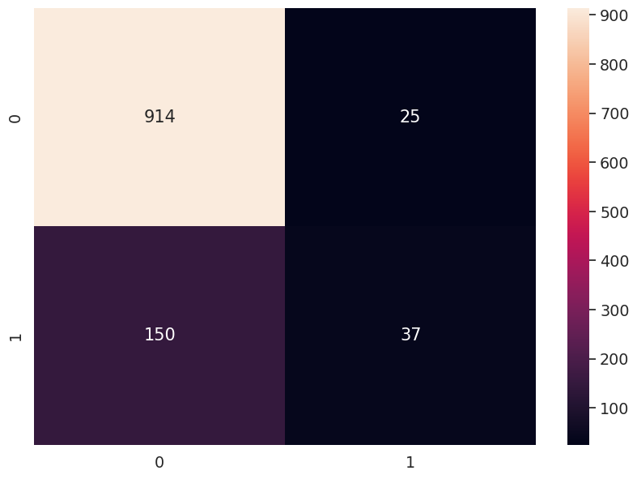

```python
# Build the confusion matrix
df_cm = pd.DataFrame(cm, index = (0, 1), columns = (0, 1))
plt.figure(figsize = (10, 7))
sns.heatmap(df_cm, annot = True, fmt ='g')
print("Test Data Accuracy: %.4f" %accuracy_score(Y_test, y_pred))
```

```python
# Generate a classification report
classification_report_result = classification_report(Y_test, y_pred)
print("Classification Report:")
print(classification_report_result)
```

```
Classification Report:
              precision    recall  f1-score   support

           0       0.86      0.97      0.91       939
           1       0.60      0.20      0.30       187

    accuracy                           0.84      1126
   macro avg       0.73      0.59      0.60      1126
weighted avg       0.82      0.84      0.81      1126
```

## Build Decision tree model

```
Decision Tree Model Evaluation:
Accuracy: 0.8978685612788633
Precision: 0.7307692307692307
Recall: 0.6096256684491979
F1 Score: 0.6647230320699709
```

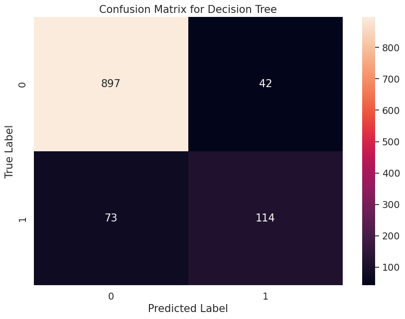

```python
# Build and train the Decision Tree model
decision_tree_classifier = DecisionTreeClassifier(random_state=0)
decision_tree_classifier.fit(X_train, Y_train)

# Predict on the test data
y_pred_dt = decision_tree_classifier.predict(X_test)

# Evaluate the Decision Tree model
print("Decision Tree Model Evaluation:")
print("Accuracy:", accuracy_score(Y_test, y_pred_dt))
print("Precision:", precision_score(Y_test, y_pred_dt))
print("Recall:", recall_score(Y_test, y_pred_dt))
print("F1 Score:", f1_score(Y_test, y_pred_dt))

# Optional: Display confusion matrix for Decision Tree
cm_dt = confusion_matrix(Y_test, y_pred_dt)
df_cm_dt = pd.DataFrame(cm_dt, index=(0, 1), columns=(0, 1))
plt.figure(figsize=(10, 7))
sns.heatmap(df_cm_dt, annot=True, fmt='g')
plt.title('Confusion Matrix for Decision Tree')
plt.xlabel('Predicted Label')
plt.ylabel('True Label')
plt.show()
```

```python
#classification report for decision tree
class_report = classification_report(Y_test, y_pred_dt)
print("Classification Report for Decision Tree:\n", class_report)
```

```
Classification Report for Decision Tree:
               precision    recall  f1-score   support

           0       0.92      0.96      0.94       939
           1       0.73      0.61      0.66       187

    accuracy                           0.90      1126
   macro avg       0.83      0.78      0.80      1126
weighted avg       0.89      0.90      0.89      1126
```

```python
from rfpimp import *
```

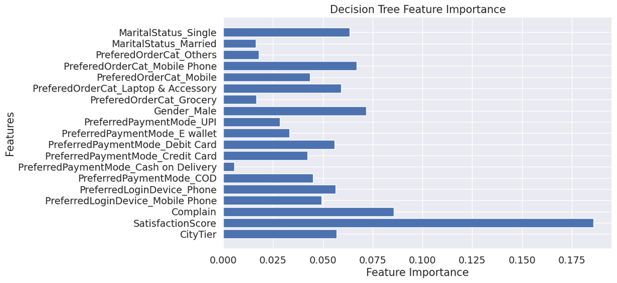

```python
#generating future importance
feature_importance1 = decision_tree_classifier.feature_importances_
feature_names2 = X_train.columns

# Create a bar plot to visualize feature importance
plt.figure(figsize=(10, 6))
plt.barh(feature_names2, feature_importance1)
plt.xlabel('Feature Importance')
plt.ylabel('Features')
plt.title('Decision Tree Feature Importance')
plt.show()
```